# Projet de biostatistiques - Ankylostome

Amandine LIAGRE - Florian BUCQUET - Rachid ABDELJABBAR

03-02-2024

# Introduction

A travers ce projet, nous allons utiliser les données provenant d’une enquête réalisée sur un échantillon d’individus en Egypte. Plus particulièrement, nous avons des informations concernant l’infection des individus par l’ankylostome. En marchant pieds nus, les individus sont contaminés via les larves des ankylostomes vivant en terre. L’infection peut aussi se produire via une ingestion d’aliments contaminés par des larves. Les différents symptômes posibles sont des éruptions et lésions cutannées aux endroits où les larves ont pénétré la peau, de la fièvre, des douleurs épigastriques, des diarrhées, de la toux, inflammation de l’intestin … . Dans les cas les plus graves, le malade peut être victime d’une perte de sang (les larves dans l’intestin se nourrissent de sang en étant accroché à sa paroi et il en résulte une potentielle anémie pour le malade), d’insuffisance cardiaque. Il existe des médicaments antiparasitaires pour traiter cette infection (albendazole, mébendazole).

L’ankylostome vit particulièrement bien dans la terre et une température aux alentours des 18°C afin que les oeufs puissent éclore. Les oeufs d’ankylostomes ont l’allure suivante:

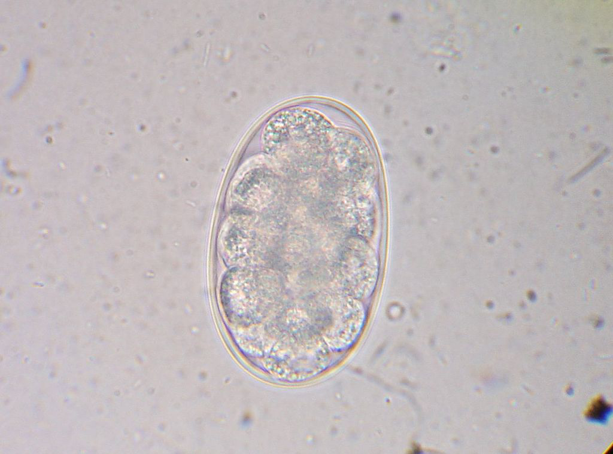

Oeufs d’Ankylostosme, par Joel Mills - CC BY-SA 3.0

Et par la suite, deviennent les des vers se propageant vers l’intestin:

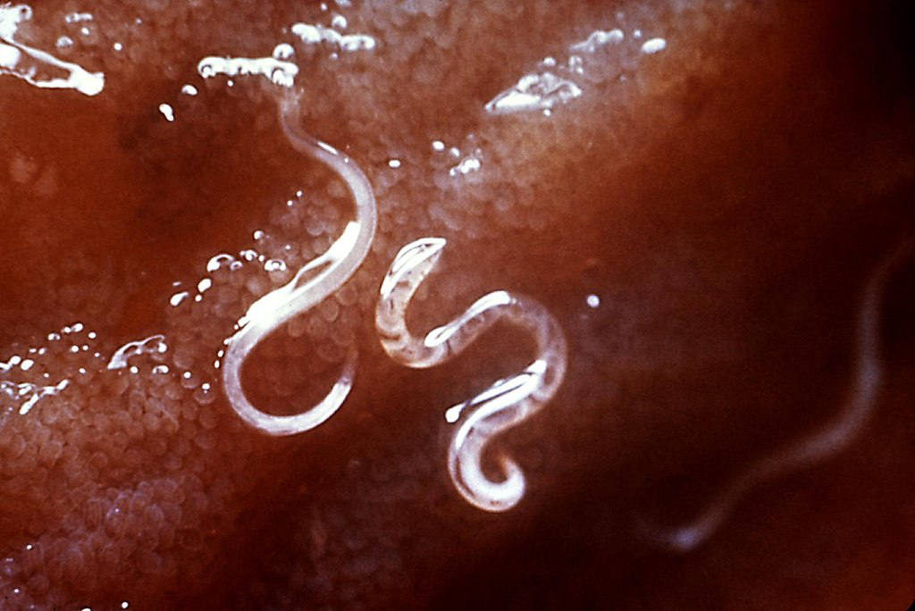

Vers d’Ankylostosme, par CDC’s Public Health Image Library

Voici le cycle parasitaire de l’ankylostome:

[figure not shown]

Cycle parasitaire de l’ankylostome, par CDC - Department of Parasitic Diseases - Domaine public

# I. Lecture des données et vérification

A travers le tableau suivant, voici un récapitulatif de nos données:

| Nom de la variable | Type | Modalités ou exemples de modalités |
| --- | --- | --- |
| id | int | 440, 336, 60, … |
| age | int | 2, 3, 4, 5, 6, 7, 8, 9, 10, 11, 12, … |
| agegr | chr | <15 yrs, 15-59 yrs, 60+ yrs |
| zone | chr | Nord, Ouest, Sud, Est |
| sexe | int | 0 (masculin ?), 1 (féminin ?) |
| chaussures | chr | “no”, “yes” |
| nb.oeufs | int | 0, 46, 184, 989, 1150, 690, … |
| intensite | chr | 0, “[1;1.999]”, “[2;+]” |
| ageclasses | chr | <16 ans, 16-49, 49 et plus |

Voici l’allure générale de nos données:

|  | id | age | agegr | zone | sexe | chaussures | nb.oeufs | intensite | ageclasses |
| --- | --- | --- | --- | --- | --- | --- | --- | --- | --- |
| 1 | 440 | 2 | <15 yrs | Nord | 0 | no | 0 | 0 | <16 ans |
| 2 | 336 | 2 | <15 yrs | Ouest | 1 | no | 46 | "[1;1.999]" | <16 ans |
| 3 | 60 | 2 | <15 yrs | Nord | 1 | no | 184 | "[1;1.999]" | <16 ans |
| 4 | 100 | 2 | <15 yrs | Ouest | 1 | no | 0 | 0 | <16 ans |
| 5 | 281 | 2 | <15 yrs | Sud | 1 | no | 0 | 0 | <16 ans |
| 6 | 90 | 2 | <15 yrs | Ouest | 0 | no | 0 | 0 | <16 ans |

## I.1 Informations concernant les individus

La table de données contient 238 hommes et 399 femmes et ils sont répartis de la manière suivante selon la zone géographique:

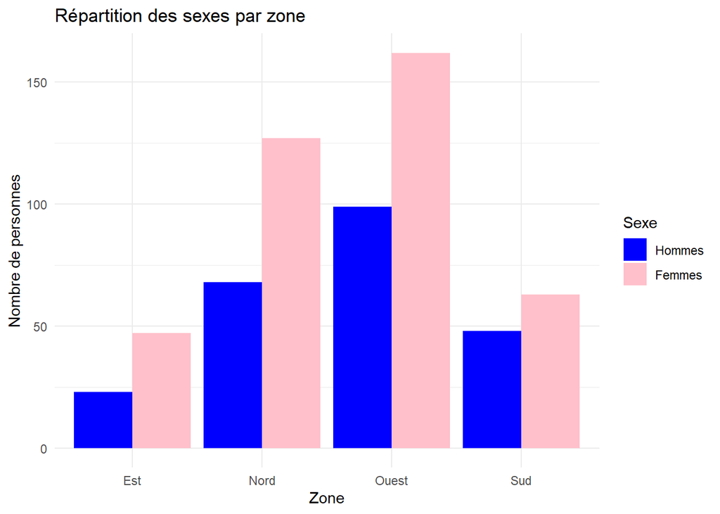

Regardons les catégories d’âges. Trois variables sont à notre disposition: age, agegr et ageclasses.

| Statistique | Valeur |
| --- | --- |
| Min. | 2.00 |
| 1st Qu. | 9.00 |
| Median | 23.00 |
| Mean | 25.94 |
| 3rd Qu. | 40.00 |
| Max. | 78.00 |

| Catégorie | Valeur |
| --- | --- |
| <15 yrs | 259 |
| 15-59 yrs | 331 |
| 60+ yrs | 47 |

| Catégorie | Valeur |
| --- | --- |
| <16 ans | 259 |
| 16-49 ans | 331 |
| 49 et plus | 47 |

## I.2 Création de la variable “malade” et observations

Suite à cette création nous constatons qu’il y a 197 personnes non malades (31% de l’échantillon) et 440 personnes malades (69% de l’échantillon), pour un total de 637 personnes.

## I.3 Quelques analyses préliminaires …

### I.3.a …via des graphiques

La répartition des sexes par zone géographique selon le porte de chaussures :

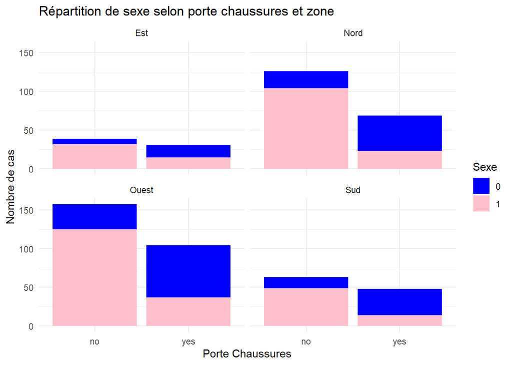

La répartition des personnes porte des chaussures selon l’âge par zone géographique :

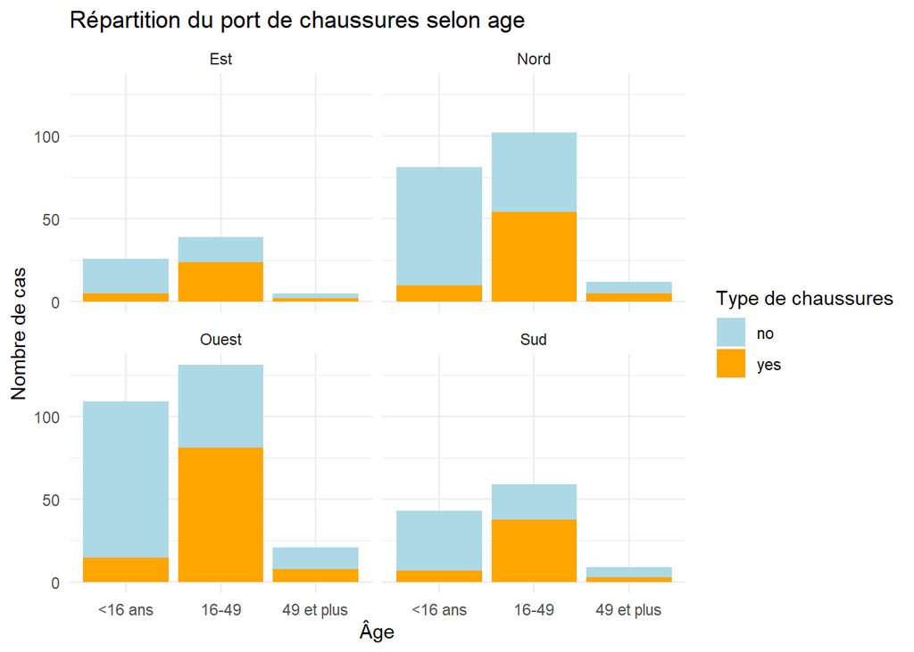

La répartition des sexes par zone géographique selon l’infection:

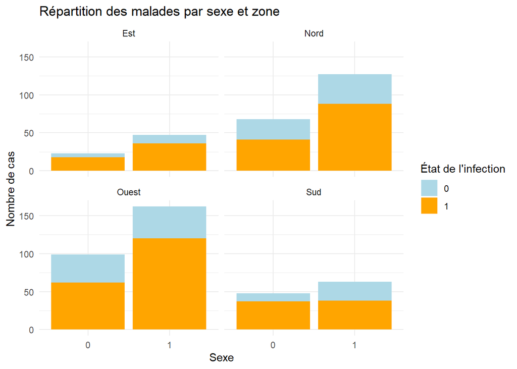

La répartition des personnes infectées et le port de chaussures:

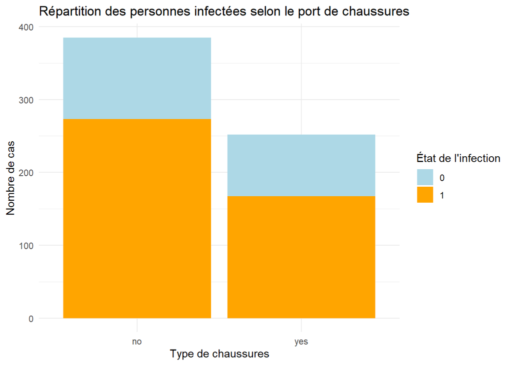

La répartition des personnes infectées selon leur âge. Pour cela nous allons créer une nouvelle variable age_categ car les deux autres variables qui classent les âges ne nous semblent pas représentatives. Voici les tranches choisies: - 0 à 5 ans exclus, - 5 ans à 10 ans exclus, - 10 ans à 18 ans exclus, - 19 ans à 30 ans exclus, - 30 à 60 ans exlus, - les plus de 60 ans

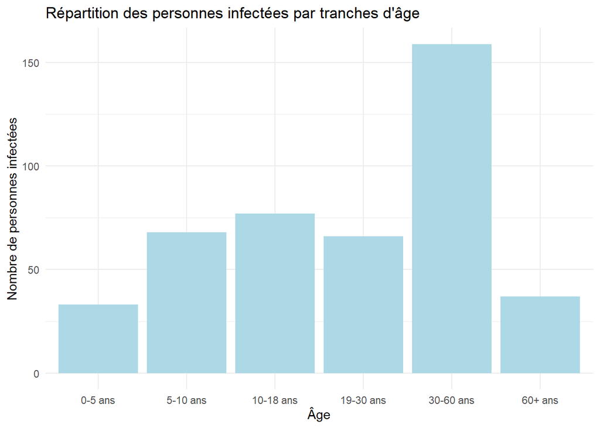

### I.3.b …via le test du khi-deux

Le $\chi^2$ permet de vérifier une relation entre deux variables qualitatives et de comparer des répartitions d’effectifs. Nous allons réaliser un text du khi-deux d’homogénéité et d’indépendance.

De plus, nous restons vigilants à la contrainte suivante : 80% des effectifs doivent être supérieurs à 5 individus.

Nous testons l’hypothèse nulle H0, les deux variables sont indépendantes contre H1, il existe une relation entre les deux variables testées.

Dans un premier temps, nous réaliserons ce test avec *zone* en tant que variable cible, avec *chaussures*, *age_categ* et *sexe*. Ensuite, nous réaliserons ce test entre *age_categ* et *chaussures*, *age_categ* et *sexe*, *chaussures* et *sexe*.

Test du khi-deux

Analyse des relations entre variables

| variable_cible | variable_testee | p_valeur | interpretation |
| --- | --- | --- | --- |
| zone | chaussures | 0.4378 | Indépendance entre zone et chaussures |
| zone | ageclasses | 0.9627 | Indépendance entre zone et ageclasses |
| zone | sexe | 0.4234 | Indépendance entre zone et sexe |
| ageclasses | chaussures | 0.0000 | Dépendance entre ageclasses et chaussures |
| ageclasses | sexe | 0.0000 | Dépendance entre ageclasses et sexe |
| chaussures | sexe | 0.0000 | Dépendance entre chaussures et sexe |

# II. Modèles

## II.1 Modèles logistiques avec une variable qualitative

La variable cible est *malade*, variable binaire où 1 représente une infection et 0 une absence d’infection.

Tout d’abord, nous allons regarder différents modèles logistiques selon seulement une variable qualitative: chaussures ; age ; sexe.

### Variable chaussures

```
##
##  no yes
## 385 252
```

$$malade = \beta_{0} +
\beta_{chaussuresno} * chaussuresno$$

```r
### MODELE DE REGRESSION - VAR chaussures ###
res_chaussures <- glm(malade ~ chaussures, family="binomial", data=data)
res_chaussures
```

```
##
## Call:  glm(formula = malade ~ chaussures, family = "binomial", data = data)
##
## Coefficients:
##  (Intercept)  chaussuresno
##       0.6753        0.2156
##
## Degrees of Freedom: 636 Total (i.e. Null);  635 Residual
## Null Deviance:       788
## Residual Deviance: 786.5     AIC: 790.5
```

```r
confint(res_chaussures, level=0.95)
```

```
##                   2.5 %    97.5 %
## (Intercept)   0.4175228 0.9405830
## chaussuresno -0.1268667 0.5565847
```

Nous obtenons $\beta_{chaussuresno}=0.2156$ et $IC_{95%} = [-0.1268667, 0.5565847]$. Le groupe de référence est représenté par la modélité “yes”. Ainsi la valeur obtenue pour $\beta_{chaussuresno} - \beta_{chaussuresyes} = ln(\frac{odds(malade=1|chaussures ="no")}{odds(malade=1|chaussures="yes")})$ est 0.2156, soit :

$$\frac{odds(malade=1|chaussures="no")}{odds(malade=1|chaussures="yes")}=
\exp(0.2156) = 1.24$$
Nous pouvons dire que la sous-population des personnes ne portant pas de chaussures a 1.24 fois plus de chance d’infection que la sous-population portant des chaussures. L’intervalle de confiance obtenue contient 0 et est large, il est difficile de conclure en raison de son imprécision.

### Variable sexe

```
##
##   0   1
## 238 399
```

Les modalités possibles de la variable *sexe* sont **O** ou **1**. La modalité “0” (homme) représente 238 observations et “1”(femme) 399 observations. Ainsi la modalité de référence déclarée sera “1” et voici le modèle considéré :

$$malade = \beta_{0} + \beta_{sexe0} *
sexe0$$

```r
### MODELE DE REGRESSION - VAR chaussures ###
res_sexe <- glm(malade ~ sexe, family="binomial", data=data)
res_sexe
```

```
##
## Call:  glm(formula = malade ~ sexe, family = "binomial", data = data)
##
## Coefficients:
## (Intercept)        sexe0
##      0.8797      -0.1992
##
## Degrees of Freedom: 636 Total (i.e. Null);  635 Residual
## Null Deviance:       788
## Residual Deviance: 786.7     AIC: 790.7
```

```r
confint(res_sexe, level=0.95)
```

```
##                  2.5 %    97.5 %
## (Intercept)  0.6671876 1.0986994
## sexe0       -0.5429823 0.1469779
```

$$\frac{odds(malade=1|sexe="0")}{odds(malade=1|sexe="1")}=
\exp(-0.1992) = 0.82$$
Nous pouvons dire que la sous-population des hommes a 0.82 fois plus de chance d’infection que la sous-population représentant les femmes, soit que les hommes ont moins de chance d’être infectés. L’intervalle de confiance obtenue contient 0 et est large, il est difficile de conclure en raison de son imprécision.